# Random Acts of Pizza

Ryan Kuhn

## The Challenge

Kaggle launched a machine learning challenge based on the Random Acts of Pizza (RAOP) project on [Reddit](http://www.reddit.com/r/Random_Acts_Of_Pizza/). In RAOP, people can buy a pizza for any random person that asks for it. People have made requests by descibing hard times, asking very politely, or even offering to write poems in return.

The purpose of this challenge was to analyze the historical requests and create an algorithm capable of predicting whether a request will be successful and recieve a free pizza.

## Exploratory Analytics and Feature Engineering

#### Load the Training Data

You can get the training dataset from the Kaggle website, but in order to download it, Kaggle requires you to sign in to your account and accept the terms of the competition. Unfortunately, they haven’t developed an API to do this with an R script so I’m going to rely on the reader to download the data themself. Here is the link to the competition page: [Link](http://www.kaggle.com/c/random-acts-of-pizza/data). The data downloads as a 1.7MB zip file in JSON format. JSON is short for Java Script Object Notation and is an alternative to XML.

#### Finding the Missing Values

With the dataset loaded, we’ll start with some exploratory analytics understand the dataset. We’ll look at the attribute names and then make several plots determine which of the attributes might add predictive power. Let’s take a quick look at the dataset and see where the missing values are. The original dataset used the character string “N/A” to refer to NA values. We’ll have to turn those values into something R understands. The NA values are in the variables shown below.

```
                        Variable NACount
 giver_username_if_known            3753
 requester_subreddits_at_request    729
 requester_user_flair               3046
```

It is interesting that kaggle website describes the **requester_user_flair** field as used to say if the requester received pizza, received pizza and gave pizza, or didn’t receive any pizza. This fields seems like it would give away the outcome of the request so we’ll check to see if its in the test dataset. This field as well as a few others are only in the training dataset. There are only 17 fields in the test set while there are 32 fields in the training set. These fields will be removed to prevent us from building model on datapoints that won’t be available later when we apply the model to the test dataset.

### Analysis of Time Values

Next, we’ll look at the success rates by time period to see if there are any trends with time. We’ll need to convert the date fields to POSIXct so the year can be extracted and then we can create a chart of the success rates. Using the table below, we can see that the requests that receive pizza has consistently decreased across the years- both proportionally and nominally. The 2011 success rate is approximately 30 percent while the 2013 rate is a little more than 20 percent. This means that a request this year is less likely to be receive a free pizza then the year before. The difference in years could have predictive power so we’ll keep it in mind for later.

```
Source: local data frame [3 x 4]

    Year Count Success Percent
  (fctr) (int)   (int)   (chr)
1   2011  1234     371   30.1%
2   2012  1493     352   23.6%
3   2013  1313     271   20.6%
```

#### Success Rate by Day of the Week

Based on the table above, it looks like requests were getting less successful with each year. Perhaps as word got out about the program there were more requesters than pizza buyers or requests became disingenuous. We’d need to do some analysis on the text to get those answers but for now we’ll take a look at the data by day of the week. This will be a test to see if the requests are more successful on the weekend for example. This data doesn’t appear to have very strong preditive power because the variance between days is not very great.

```
Source: local data frame [7 x 4]

    weekday Count Success Percent
     (fctr) (int)   (int)   (chr)
1    Friday   544     131   24.1%
2    Monday   574     153   26.7%
3  Saturday   522     121   23.2%
4    Sunday   585     135   23.1%
5  Thursday   550     164   29.8%
6   Tuesday   606     134   22.1%
7 Wednesday   659     156   23.7%
```

#### Converting Binary Variables

One of the fields is called giver_username_if_known. This variable is particulary interesting because, logically, in order for a giver to be known, they must first have given a pizza. We’ll convert this variable to a binary value: 0 for an NA value and 1 for when the giver username exists. We can create a table showing the success rates by this binary value. The table shows us that whenerver there is a value in the giver_username_if_known variable and it is not an NA, then the request was successful. That makes sense and we expected that result.

```
Source: local data frame [2 x 4]

  giver_username_if_known Count Success Percent
                    (dbl) (int)   (int)   (chr)
1                       0  3753     707   18.8%
2                       1   287     287    100%
```

#### Does Adding Images to the Request Help?

Next, we’ll see look at the impact of attaching an image to the request. Per the research paper referenced in the competition wesite, attaching an image is supposed to increase the success rates. We’ll see if this holds true in our training dataset. From the table below, it appears that this is correct but there are very few instances where an image was attached. This variable may not add much to our model.

```
Source: local data frame [2 x 4]

  Image Count Success percent
  (dbl) (int)   (int)   (chr)
1     0  3948     954   24.2%
2     1    92      40   43.5%
```

#### Age of Reddit Account

The length of time the requester has had an account on Reddit may have an influence on whether the request is successful. This analysis will seperate users that are not likely contributors to the community and less likely to receive a free pizza. The difference in the success rates seems to indicate this variable could have predictive power. Band new accounts are approximately 10% LESS successful than accounts open for more than a week.

```
Source: local data frame [2 x 4]

  Acct.Age Count Success Percent
     (dbl) (int)   (int)   (chr)
1        0  1045     180   17.2%
2        1  2995     814   27.2%
```

Create a binary variable by the number of requester comments. The request is significantly more successful if the requester has more than 8 comments in the RAOP community. However, like the image variable, this may not add much predictive power from the small number of instances with more than 8 comments in the training set.

```
Source: local data frame [2 x 4]

  BnRAOP Count Success Percent
   (dbl) (int)   (int)   (chr)
1      0  3973     947   23.8%
2      1    67      47   70.1%
```

#### Text Analysis with Word Count

You can imagine that the text of the request is very important to whether the someone buys a pizza or not. It has to grab the readers attention, present a compelling case, or entertain the reader. The text analysis starts with a simple analysis of the word count. Each request will be split and get the length, or count, of the number of words. We’ll start by grouping the requests by percentiles and determining if the success rates have enough variance to give predictive power.

```
Source: local data frame [2 x 4]

  Word.bin Count Success Percent
     (int) (int)   (int)   (chr)
1        1  2046     407   19.9%
2        2  1994     587   29.4%
```

## Create the Models

#### Baseline Model

The baseline model is a simple average of how many requests were successful. In this simple model, we would use this average as the probability that each request was succesful. We’d predict that every each observation had a 24.6 percent chance of success and therefore would most likely fail.

```
     N Success Percent
1 3030     746   24.6%
```

#### Logistic Regression Model

Linear regression models are useful for predicting continuous (numeric) variables. However, the target value in this challenge are binary and can only be values of 1 or 0. They either successfully receive a pizza or do not receive a pizza. Instead, logistic regression will be more useful because it will produce probability that the target value is 1.

```
Call:
glm(formula = requester_received_pizza ~ giver_username_if_known +
    BnRAOP + Word.bin + Year * weekday + Acct.Age, family = binomial,
    data = ttrain)

Deviance Residuals:
    Min       1Q   Median       3Q      Max
-2.1216  -0.6354  -0.5157  -0.3006   2.5976

Coefficients:
                           Estimate Std. Error z value Pr(>|z|)
(Intercept)                -2.23559    0.28470  -7.852 4.08e-15 ***
giver_username_if_known    19.15604  258.48300   0.074 0.940923
BnRAOP                      2.55582    0.35703   7.158 8.16e-13 ***
Word.bin                    0.47414    0.10317   4.596 4.32e-06 ***
Year2012                   -0.77364    0.31777  -2.435 0.014910 *
Year2013                   -1.11446    0.32139  -3.468 0.000525 ***
weekdayMonday               0.26410    0.28857   0.915 0.360093
weekdaySaturday            -0.11094    0.30432  -0.365 0.715440
weekdaySunday              -0.33094    0.30612  -1.081 0.279659
weekdayThursday             0.07297    0.28919   0.252 0.800781
weekdayTuesday             -0.21589    0.29987  -0.720 0.471570
weekdayWednesday           -0.41673    0.28124  -1.482 0.138401
Acct.Age                    0.87068    0.13108   6.643 3.08e-11 ***
Year2012:weekdayMonday     -0.33542    0.44104  -0.761 0.446944
Year2013:weekdayMonday     -0.06178    0.45058  -0.137 0.890936
Year2012:weekdaySaturday    0.11317    0.45558   0.248 0.803813
Year2013:weekdaySaturday   -0.35200    0.48982  -0.719 0.472369
Year2012:weekdaySunday      0.45464    0.44369   1.025 0.305514
Year2013:weekdaySunday      0.29957    0.46159   0.649 0.516344
Year2012:weekdayThursday    0.13103    0.43881   0.299 0.765239
Year2013:weekdayThursday   -0.01809    0.46641  -0.039 0.969067
Year2012:weekdayTuesday    -0.32331    0.46696  -0.692 0.488702
Year2013:weekdayTuesday     0.21007    0.45092   0.466 0.641309
Year2012:weekdayWednesday  -0.00568    0.45046  -0.013 0.989939
Year2013:weekdayWednesday   0.60744    0.43932   1.383 0.166765
---
Signif. codes:  0 '***' 0.001 '**' 0.01 '*' 0.05 '.' 0.1 ' ' 1

(Dispersion parameter for binomial family taken to be 1)

    Null deviance: 3382.2  on 3029  degrees of freedom
Residual deviance: 2531.5  on 3005  degrees of freedom
AIC: 2581.5

Number of Fisher Scoring iterations: 16
```

#### Classification Model

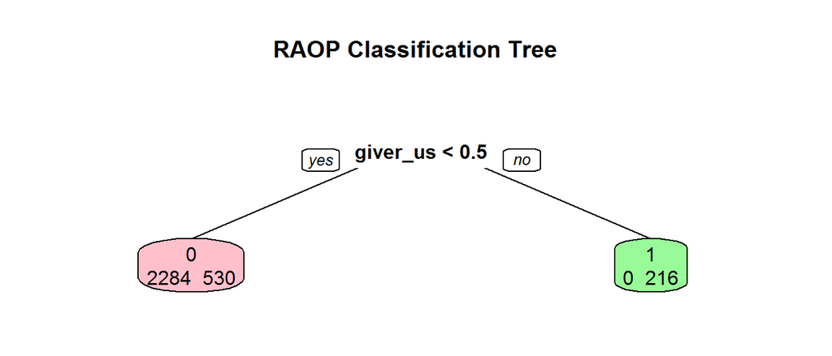

#### Score the Model

*Work in Progress*

```
    FALSE TRUE
  0   762    0
  1   177   71
```

```
Area under the curve: 0.7692
```

## Apply the Model to the Test Data

*Work in Progress* The test set will be prepared using the same functions as were used on the training dataset.